# Business Statistics Mid-Term Assessment IB94X0 2022-2023 #1

2224040

This is to certify that the work I am submitting is my own. All external references and sources are clearly acknowledged and identified within the contents. I am aware of the University of Warwick regulation concerning plagiarism and collusion.

No substantial part(s) of the work submitted here has also been submitted by me in other assessments for accredited courses of study, and I acknowledge that if this has been done an appropriate reduction in the mark I might otherwise have received will be made.

# Section 1

```r
# install.packages("emmeans")
# install.packages("gridExtra")
library(tidyverse)
library(emmeans)
library(gridExtra)
library(knitr)
library(kableExtra)
library(RColorBrewer)
options(width=100)
```

This report completes the requests of a panel of Fire service managers and local politicians, performing the specific analyses requested.

1. Provide the costs of responding to fires and false alarms
2. Perform the distribution of response times for the three different types of incident
3. Perform the distribution of response times
4. Perform the distribution of response times for the three different types of incident
5. Perform summary of special service response times
6. Perform a two sample t-test to see if there is a significant difference in the average response time for Ealing borough compared to Greenwich borough
7. Perform confidence intervals for the estimates for each borough as well as the CI for the difference between boroughs

## Data Dictionary

This data is provided by the London Fire Brigade. The variables are described in the table below

| Variable | Description |
| --- | --- |
| IncidentNumber | LFB unique identifier for the incident |
| DateOfCall | Date the 999 call for the incident was received by Brigade Control |
| TimeOfCall | Time the 999 call for the incident was received Brigade Control |
| IncidentGroup | High level description of the incident; Fire, Special Service or False Alarm |
| StopCodeDescription | Stop code is an LFB short description of the type of incident attended |
| SpecialServiceType | Special Services are emergencies other than Fire that the LFB attend. Special Service Type categorises these into 21 different services |
| PropertyCategory | A high level group to describe where the incident took place |
| PropertyType | A more detailed description of where the incident took place |
| AddressQualifier | This describes where the incident happened in relation to the address recorded |
| Postcode_full | The full postcode for the address recorded for the incident. This is withheld for incidents where the property category is Dwelling in consideration of Data Protection principles |
| Postcode_district | The partial district postcode (eg SE1) for the address recorded for the incident. |
| WardCode | The Ward Code for the incident address recorded |
| WardName | The Ward Name for the incident address recorded |
| BoroughCode | The Borough Code for the incident address recorded |
| BoroughName | The Borough Code for the incident address recorded |
| Easting_m | The map easting coordinate for the incident location (to the nearest meter). This is withheld for incidents where the property category is Dwelling |
| Northing_m | The map northing coordinate for the incident location (to the nearest meter). This is withheld for incidents where the property category is Dwelling |
| Easting_rounded | The map easting representing the centre of a 100x100m area where the incident occurred. |
| Northing_rounded | The map northing representing the centre of a 100x100m area where the incident occurred. |
| FRS | The name of the Fire & Rescue Service area where the incident occurred; either London or the name of the neighbouring brigade where incident happen ‘over-the-border’ |
| IncidentStationGround | A description of the fire station area (“Ground”) where the incident happened. |
| FirstPumpArriving_AttendanceTime | The attendance time (in seconds) for the first fire engine to arrive after it has been mobilised from a fire station (or other location if it was mobile by Brigade Control at the time of the call). |
| FirstPumpArriving_DeployedFromStation | The fire station where the fire engine shown as being the first (the time in the above field) was sent from. |
| SecondPumpArriving_AttendanceTime | The attendance time (in seconds) for the second fire engine to arrive after it has been mobilised |
| SecondPumpArriving_DeployedFromStation | The fire station where the fire engine shown as being the second (the time in the above field) was sent from. |
| NumStationsWithPumpsAttending | The number of fire stations where fire engines were sent to support the incident. For large incidents this will include any stations involved in supplying additional and/or relief fire crews. |
| NumPumpsAttending | The total number of fire engines in attendance at the incident (excluding relief fire crews) |
| Notional Cost (£) | An estimate of the cost of the incident response |

## Read Data

```r
fire_data <- read_csv("London_Fire_data.csv")
```

## Provide the costs of responding to fires and false alarms

```r
fire_data2 <- fire_data %>% filter(!is.na(`Notional Cost (£)`))
( fires_cost <- sum(fire_data2$`Notional Cost (£)`) )
```

```
## [1] 151121790
```

```r
false_alarms <- fire_data2 %>% filter(IncidentGroup == "False Alarm")
( false_alarms_cost <- sum(false_alarms$`Notional Cost (£)`) )
```

```
## [1] 61249812
```

```r
( mean_fire_cost <- mean(fire_data2$`Notional Cost (£)`) )
```

```
## [1] 471.8663
```

```r
( mean_false_alarms_cost <- mean(false_alarms$`Notional Cost (£)`) )
```

```
## [1] 378.3796
```

## Perform the distribution of response times

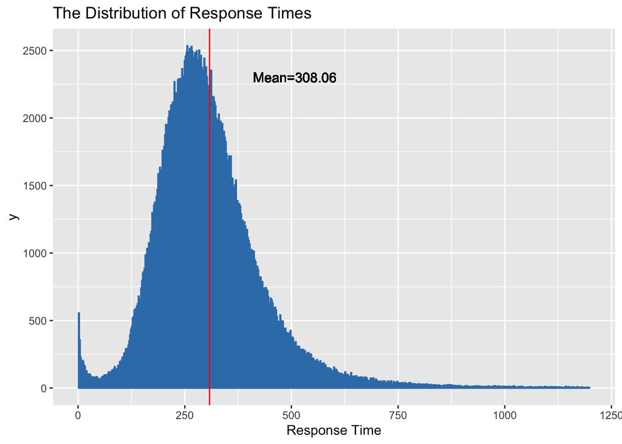

```r
response <- filter(fire_data, FirstPumpArriving_AttendanceTime!=0)
ggplot(response) +
  geom_histogram(aes(x=response$FirstPumpArriving_AttendanceTime), binwidth = 2, color=brewer.pal(7, "Set1")[2]) +
  ggtitle("The Distribution of Response Times") +
  geom_vline(aes(xintercept = mean(response$FirstPumpArriving_AttendanceTime)), colour="red") +
  labs(x="Response Time") +
  geom_text(aes(x=mean(response$FirstPumpArriving_AttendanceTime)+200, label=paste0("Mean=", round(mean(response$FirstPumpArriving_AttendanceTime), 2)), y=2300))
```

## Perform the distribution of response times for the three different types of incident

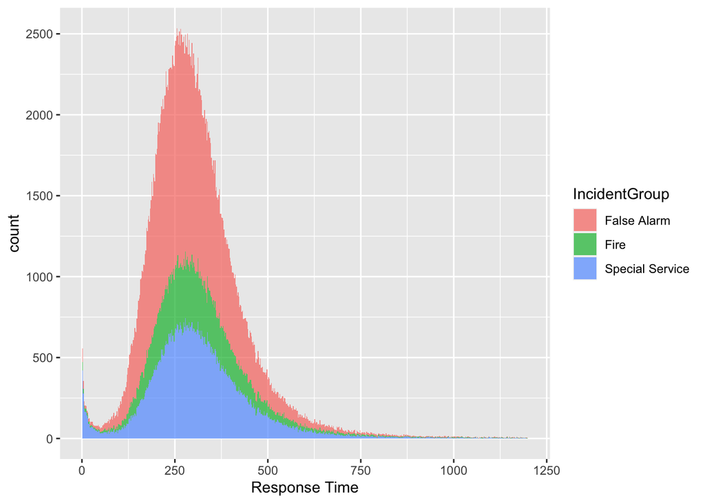

```r
ggplot(response) + geom_histogram(aes(x = response$FirstPumpArriving_AttendanceTime, fill = IncidentGroup), binwidth = 2, alpha = 0.7) + labs(x="Response Time")
```

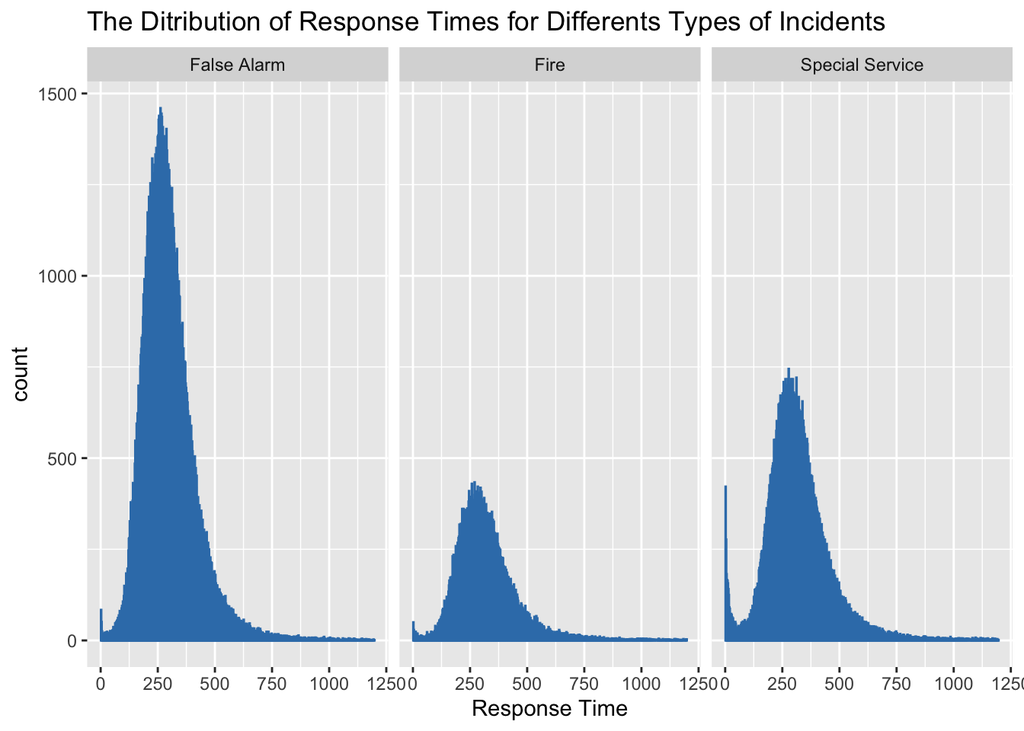

```r
ggplot(response) +
  geom_histogram(aes(x = response$FirstPumpArriving_AttendanceTime), binwidth = 2, color=brewer.pal(7, "Set1")[2]) +
  ggtitle("The Ditribution of Response Times for Differents Types of Incidents") +
  facet_grid(~ IncidentGroup) +
  labs(x="Response Time")
```

## Perform summary of special service response times

```r
sp_time <- response %>% filter(IncidentGroup == 'Special Service')
sp_group <- sp_time %>% group_by(SpecialServiceType) %>% summarise(n=n(),  mean=mean(FirstPumpArriving_AttendanceTime), '10th_percentile'=quantile(FirstPumpArriving_AttendanceTime, c(0.1)), '90th_percentile'=quantile(FirstPumpArriving_AttendanceTime, c(0.9)))
sp_group
```

```
## # A tibble: 21 × 5
##    SpecialServiceType               n  mean `10th_percentile` `90th_percentile`
##    <chr>                        <int> <dbl>             <dbl>             <dbl>
##  1 Advice Only                   1817  320.              188               462.
##  2 Animal assistance incidents   2157  341.              190               517.
##  3 Assist other agencies         4339  317.              182               462
##  4 Effecting entry/exit         23300  317.              182               470
##  5 Evacuation (no fire)           656  327.              192.              474.
##  6 Flooding                     20428  328.              191               485
##  7 Hazardous Materials incident  2518  316.              185               463.
##  8 Lift Release                  4506  307.              178               450
##  9 Making Safe (not RTC)         3344  321.              177               494
## 10 Medical Incident              2080  222.                8               433
## # … with 11 more rows
```

## Perform a two sample t-test to see if there is a significant difference in the average response time for Ealing borough compared to Greenwich borough

```r
ealing.vs.greenwich <- fire_data %>% filter(IncGeo_BoroughName == "EALING" | IncGeo_BoroughName =="GREENWICH")
ealing.vs.greenwich <- ealing.vs.greenwich %>% filter(!is.na(FirstPumpArriving_AttendanceTime))
t.test(FirstPumpArriving_AttendanceTime~IncGeo_BoroughName, data=ealing.vs.greenwich)
```

```
##
##  Welch Two Sample t-test
##
## data:  FirstPumpArriving_AttendanceTime by IncGeo_BoroughName
## t = 2.8542, df = 19303, p-value = 0.00432
## alternative hypothesis: true difference in means between group EALING and group GREENWICH is not equal to 0
## 95 percent confidence interval:
##  1.739777 9.368041
## sample estimates:
##    mean in group EALING mean in group GREENWICH
##                316.9342                311.3803
```

## Perform confidence intervals for the estimates for each borough as well as the CI for the difference between boroughs

```r
eal.grn <- lm(FirstPumpArriving_AttendanceTime~IncGeo_BoroughName, data=ealing.vs.greenwich)
( eal.grn.emm <- emmeans(eal.grn, ~IncGeo_BoroughName) )
```

```
##  IncGeo_BoroughName emmean   SE    df lower.CL upper.CL
##  EALING                317 1.34 19445      314      320
##  GREENWICH             311 1.42 19445      309      314
##
## Confidence level used: 0.95
```

```r
( eal.grn.contrast <- confint(pairs(eal.grn.emm)) )
```

```
##  contrast           estimate   SE    df lower.CL upper.CL
##  EALING - GREENWICH     5.55 1.95 19445     1.73     9.38
##
## Confidence level used: 0.95
```

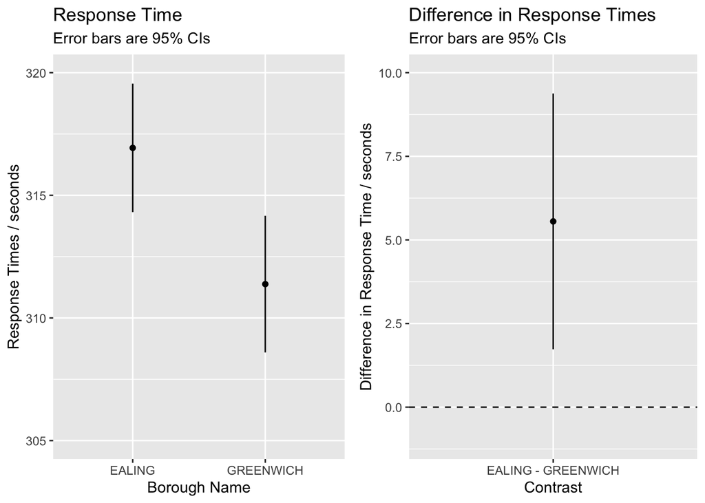

```r
grid.arrange(
    ggplot(summary(eal.grn.emm), aes(x=IncGeo_BoroughName, y=emmean, ymin=lower.CL, ymax=upper.CL)) +
        geom_point() + geom_linerange() +
        labs(y="Response Times / seconds", x="Borough Name", subtitle="Error bars are 95% CIs", title="Response Time") + ylim(305, 320),
    ggplot(eal.grn.contrast, aes(x=contrast, y=estimate, ymin=lower.CL, ymax=upper.CL)) +
        geom_point() + geom_linerange() +
        labs(y="Difference in Response Time / seconds", x="Contrast", subtitle="Error bars are 95% CIs", title="Difference in Response Times") + ylim(-1,10) +
        geom_hline(yintercept=0, lty=2),
    ncol=2
)
```